# Classification

In your second homework you need to create a model that predicts which passengers survived the Titanic shipwreck.

```python
import pandas as pd
import numpy as np
import datetime
import sys
import os
import random
import matplotlib.pyplot as plt
from sklearn.model_selection import train_test_split, KFold, GridSearchCV
from sklearn import metrics
import seaborn as sns
from scipy.stats import skew
from sklearn.tree import DecisionTreeClassifier
from sklearn.metrics import accuracy_score
from sklearn.preprocessing import OneHotEncoder
from sklearn.ensemble import RandomForestClassifier
from sklearn.metrics import precision_score, recall_score, f1_score, confusion_matrix
```

```python
train_df=pd.read_csv('train.csv')
test_df=pd.read_csv('test.csv')
```

# Data exploration

We check the shape of train and test dataframes and also show a selection of rows, to have an initial understanding of the data.

```python
train_df.sample(5).head()
```

|  | PassengerId | Survived | Pclass | Name | Sex | Age | SibSp | Parch | Ticket | Fare | Cabin | Embarked |
| --- | --- | --- | --- | --- | --- | --- | --- | --- | --- | --- | --- | --- |
| 177 | 178 | 0 | 1 | Isham, Miss. Ann Elizabeth | female | 50.0 | 0 | 0 | PC 17595 | 28.7125 | C49 | C |
| 423 | 424 | 0 | 3 | Danbom, Mrs. Ernst Gilbert (Anna Sigrid Maria ... | female | 28.0 | 1 | 1 | 347080 | 14.4000 | NaN | S |
| 655 | 656 | 0 | 2 | Hickman, Mr. Leonard Mark | male | 24.0 | 2 | 0 | S.O.C. 14879 | 73.5000 | NaN | S |
| 684 | 685 | 0 | 2 | Brown, Mr. Thomas William Solomon | male | 60.0 | 1 | 1 | 29750 | 39.0000 | NaN | S |
| 710 | 711 | 1 | 1 | Mayne, Mlle. Berthe Antonine ("Mrs de Villiers") | female | 24.0 | 0 | 0 | PC 17482 | 49.5042 | C90 | C |

```python
test_df.sample(5).head()
```

|  | PassengerId | Pclass | Name | Sex | Age | SibSp | Parch | Ticket | Fare | Cabin | Embarked |
| --- | --- | --- | --- | --- | --- | --- | --- | --- | --- | --- | --- |
| 384 | 1276 | 2 | Wheeler, Mr. Edwin Frederick"" | male | NaN | 0 | 0 | SC/PARIS 2159 | 12.8750 | NaN | S |
| 329 | 1221 | 2 | Enander, Mr. Ingvar | male | 21.0 | 0 | 0 | 236854 | 13.0000 | NaN | S |
| 102 | 994 | 3 | Foley, Mr. William | male | NaN | 0 | 0 | 365235 | 7.7500 | NaN | Q |
| 111 | 1003 | 3 | Shine, Miss. Ellen Natalia | female | NaN | 0 | 0 | 330968 | 7.7792 | NaN | Q |
| 394 | 1286 | 3 | Kink-Heilmann, Mr. Anton | male | 29.0 | 3 | 1 | 315153 | 22.0250 | NaN | S |

```python
print("Train: rows:{} cols:{}".format(train_df.shape[0], train_df.shape[1]))
print("Test:  rows:{} cols:{}".format(test_df.shape[0], test_df.shape[1]))
```

```
Train: rows:891 cols:12
Test:  rows:418 cols:11
```

Both **train** and **test** files contains the following values:

- **PassengerID** - the index of the passenger (in the dataset);
- **PClass** - the class of the passenger (from 1 to 3);
- **Name** - the name of the passenger;
- **Sex** - the sex of the passenger (female or male);
- **Age** - the age (where available) of the passenger;
- **SibSp** - the number of sibilings / spouses aboard of Titanic;
- **Parch** - the number of parents / children aboard of Titanic;
- **Ticket** - the ticket number;
- **Fare** - the passenger fare (ticket cost);
- **Cabin** - the cabin number;
- **Embarked** - the place of embarcation of the passenger (C = Cherbourg, Q = Queenstown, S = Southampton).

The **train** data has as well the target value, **Survived**.

It is important to have a good understanding of the data before going to create a model. Therefore we will explore the features.

Let's start by checking if there are missing data and unlabeled data.

Next, analyze the dependencies of the target variable on various features, such as Age, Sex, and so on, using approaches similar to those in the first homework.

Draw conclusions about what affects whether the passenger survives, check the distribution of features in the train and test data.

Check if there are missing data and unlabeled data.

```python
train_df.describe()
```

|  | PassengerId | Survived | Pclass | Age | SibSp | Parch | Fare |
| --- | --- | --- | --- | --- | --- | --- | --- |
| count | 891.000000 | 891.000000 | 891.000000 | 714.000000 | 891.000000 | 891.000000 | 891.000000 |
| mean | 446.000000 | 0.383838 | 2.308642 | 29.699118 | 0.523008 | 0.381594 | 32.204208 |
| std | 257.353842 | 0.486592 | 0.836071 | 14.526497 | 1.102743 | 0.806057 | 49.693429 |
| min | 1.000000 | 0.000000 | 1.000000 | 0.420000 | 0.000000 | 0.000000 | 0.000000 |
| 25% | 223.500000 | 0.000000 | 2.000000 | 20.125000 | 0.000000 | 0.000000 | 7.910400 |
| 50% | 446.000000 | 0.000000 | 3.000000 | 28.000000 | 0.000000 | 0.000000 | 14.454200 |
| 75% | 668.500000 | 1.000000 | 3.000000 | 38.000000 | 1.000000 | 0.000000 | 31.000000 |
| max | 891.000000 | 1.000000 | 3.000000 | 80.000000 | 8.000000 | 6.000000 | 512.329200 |

```python
train_df.describe(include='object')
```

|  | Name | Sex | Ticket | Cabin | Embarked |
| --- | --- | --- | --- | --- | --- |
| count | 891 | 891 | 891 | 204 | 889 |
| unique | 891 | 2 | 681 | 147 | 3 |
| top | Braund, Mr. Owen Harris | male | 347082 | B96 B98 | S |
| freq | 1 | 577 | 7 | 4 | 644 |

We can see that there are missing values in Age, Cabin and Embarked columns.

```python
survived_counts=train_df['Survived'].value_counts()
survived_percentage=survived_counts/len(train_df)*100
print(f"Percentage of people who survived: {survived_percentage[1]:.1f}%")
print(f"Percentage of people who did not survive: {survived_percentage[0]:.1f}%")
```

[output not shown]

We can see that 62% of passengers died and 38% of passengers survived.

#### Let's analyze the dependencies of the target variable on various features and their distributions.

```python
# Correlation heatmap
sns.heatmap(train_df.corr(), cmap='vlag', annot=True, fmt='0.2f');
```

[output not shown]

We can notice higher correlation between target variable and passenger class compared to other features. There is also connection between passenger class and age, passenger class and fare etc. Overall, correlations between features are quite high.

#### 1. Age

```python
fig, axes = plt.subplots(1, 2, figsize=(12, 4))

# Plot the training dataset age distribution
axes[0].set_title('Training Set - Age Distribution')
train_df['Age'].hist(bins=50, ax=axes[0])
axes[0].set_xlabel('Age')
axes[0].set_ylabel('Count')

# Plot the test dataset age distribution
axes[1].set_title('Test Set - Age Distribution')
test_df['Age'].hist(bins=50, ax=axes[1])
axes[1].set_xlabel('Age')
axes[1].set_ylabel('Count');
```

[output not shown]

```python
# Compute skewness for age in train_df and test_df
skewness_train = skew(train_df['Age'].dropna())
skewness_test = skew(test_df['Age'].dropna())

print(f"Skewness of Age for Train DataFrame: {skewness_train:.2f}")
print(f"Skewness of Age for Test DataFrame: {skewness_test:.2f}")
```

[output not shown]

Age distribution is close to normal distribution with skewness to the right.

```python
# Dependenciy of the target variable on Age
plot=sns.displot(train_df, x='Age', hue='Survived')
plot.set(title='Dependency of the target variable on Age');
```

[output not shown]

```python
plt.figure(figsize=(10, 6))
sns.kdeplot(train_df[train_df['Survived'] == 0]['Age'], label='Not Survived', color='red')
sns.kdeplot(train_df[train_df['Survived'] == 1]['Age'], label='Survived', color='green')

plt.title('Dependence between Survival and Age (Kernel Density Estimate)')
plt.xlabel('Age')
plt.ylabel('Density')
plt.legend()
plt.show()
```

[output not shown]

We see that age doesn't strongly influence the target variable.

#### 2. The class of the passenger

```python
fig, axes = plt.subplots(1, 2, figsize=(12, 4))

axes[0].set_title('Training Set - The class of the passenger distribution')
train_df['Pclass'].hist(ax=axes[0])
axes[0].set_xlabel('Passenger Class')
axes[0].set_ylabel('Count');

axes[1].set_title('Test Set - The class of the passenger distribution')
test_df['Pclass'].hist(ax=axes[1])
axes[1].set_xlabel('Passenger Class')
axes[1].set_ylabel('Count');
```

[output not shown]

The analysis of passenger class distribution in both the training and test datasets reveals that the 3rd class has the highest number of passengers. The 1st class has a slightly higher passenger count compared to the 2nd class in both datasets.

```python
# Dependenciy of the target variable on Passenger Class
sns.countplot(x='Pclass', hue='Survived', data=train_df)
plt.title('Survival Count by Passenger Class')
plt.xlabel('Passenger Class')
plt.ylabel('Count');
```

[output not shown]

```python
died_third_class_counts = len(train_df[(train_df['Pclass'] == 3) & (train_df['Survived'] == 0)])
died_overall = len(train_df[train_df['Survived'] == 0])
died_third_class_percentage = died_third_class_counts / died_overall * 100

survived_first_class_counts = len(train_df[(train_df['Pclass'] == 1) & (train_df['Survived'] == 1)])
survived_overall = len(train_df[train_df['Survived'] == 1])
survived_first_class_percentage = survived_first_class_counts / survived_overall * 100

print(f"Percentage of third class passengers among those who did not survive: {died_third_class_percentage:.1f}%")
print(f"Percentage of first class passengers among those who survived: {survived_first_class_percentage:.1f}%")
```

[output not shown]

We can see that 68% of people who did not survive belong to the 3rd class. The highest percentage of survivors, 40%, is observed among people from the first class.

#### 3. Sex

```python
fig, axes = plt.subplots(1, 2, figsize=(12, 4))

# Plot the training dataset age distribution
axes[0].set_title('Training Set - Sex Distribution')
train_df['Sex'].hist(ax=axes[0])
axes[0].set_xlabel('Sex')
axes[0].set_ylabel('Count')

# Plot the test dataset age distribution
axes[1].set_title('Test Set - Sex Distribution')
test_df['Sex'].hist(ax=axes[1])
axes[1].set_xlabel('Sex')
axes[1].set_ylabel('Count');
```

[output not shown]

```python
male_counts=len(train_df[train_df['Sex']=='male'])
female_counts=len(train_df[train_df['Sex']=='female'])
male_percentage=male_counts/(male_counts+female_counts)*100
female_percentage=female_counts/(male_counts+female_counts)*100

print(f"The percentage of male passengers: {male_percentage:.1f}%")
print(f"The percentage of female passengers: {female_percentage:.1f}%")
```

[output not shown]

There are 65% of male passengers and 35% of female passengers.

```python
# Dependenciy of the target variable on Sex
sns.countplot(x='Sex', hue='Survived', data=train_df)
plt.title('Survival Count by Sex')
plt.xlabel('Sex')
plt.ylabel('Count');
```

[output not shown]

```python
survived_overall = len(train_df[train_df['Survived'] == 1])
survived_male=len(train_df[(train_df['Sex']=='male')&(train_df['Survived']==1)])
survived_female=len(train_df[(train_df['Sex']=='female')&(train_df['Survived']==1)])
survived_male_percentage=survived_male/survived_overall*100
survived_female_percentage=survived_female/survived_overall*100

print(f"The percentage of males that survived: {survived_male_percentage: .1f}%")
print(f"The percentage of females that survived: {survived_female_percentage: .1f}%")
```

[output not shown]

Among survived passengers there were 68% of females and 32% of males.

```python
# Count of passengers by passenger class and sex
plot = sns.catplot(x='Pclass', hue='Sex', data=train_df, kind='count')
plot.set(title='Count of passengers by passenger class and sex');
```

[output not shown]

In the third class, there are a lot more males than females, when compared to the other classes.

#### 4. The number of sibilings / spouses

```python
fig, axes = plt.subplots(1, 2, figsize=(12, 4))

# Plot the training dataset age distribution
axes[0].set_title('Training Set - Distribution of the number of sibilings / spouses')
train_df['SibSp'].hist(bins=20, ax=axes[0])
axes[0].set_xlabel('The number of sibilings / spouses')
axes[0].set_ylabel('Count')

# Plot the test dataset age distribution
axes[1].set_title('Test Set - Distribution of the number of sibilings / spouses')
test_df['SibSp'].hist(bins=20, ax=axes[1])
axes[1].set_xlabel('The number of sibilings / spouses')
axes[1].set_ylabel('Count');
```

[output not shown]

We can see that most passengers don't have sibilings / spouses, or have 1 sibilings / spouses.

#### 4. The number of parents / children

```python
fig, axes = plt.subplots(1, 2, figsize=(12, 4))

# Plot the training dataset age distribution
axes[0].set_title('Training Set - Distribution of the number of parents / children')
train_df['Parch'].hist(bins=20,ax=axes[0])
axes[0].set_xlabel('The number of parents / children')
axes[0].set_ylabel('Count')

# Plot the test dataset age distribution
axes[1].set_title('Test Set - Distribution of the number of parents / children')
test_df['Parch'].hist(bins=20, ax=axes[1])
axes[1].set_xlabel('The number of parents / children')
axes[1].set_ylabel('Count');
```

[output not shown]

Most passengers do not have parents / children, or have 1 or 2 parents / children.

#### 5. Fare

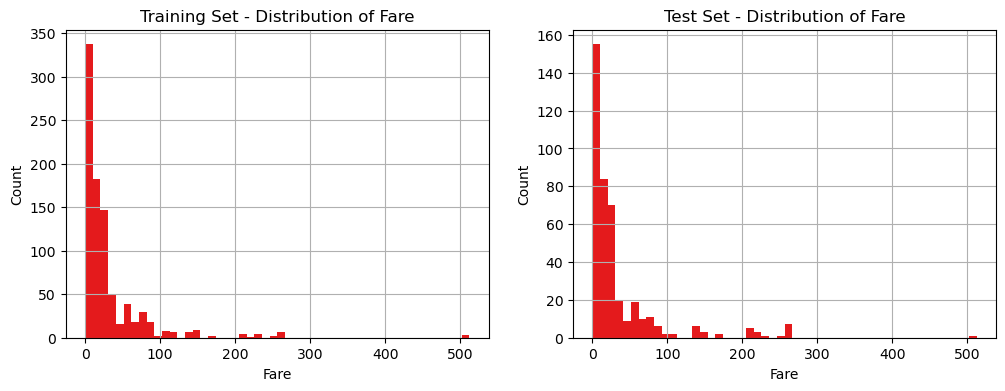

```python
fig, axes = plt.subplots(1, 2, figsize=(12, 4))

# Plot the training dataset age distribution
axes[0].set_title('Training Set - Distribution of Fare')
train_df['Fare'].hist(bins=50,ax=axes[0])
axes[0].set_xlabel('Fare')
axes[0].set_ylabel('Count')

# Plot the test dataset age distribution
axes[1].set_title('Test Set - Distribution of Fare')
test_df['Fare'].hist(bins=50, ax=axes[1])
axes[1].set_xlabel('Fare')
axes[1].set_ylabel('Count');
```

```python
fare_skewness_train = skew(train_df['Fare'])
print(f"Skewness of Fare for Train DataFrame: {fare_skewness_train:.2f}")
```

```
Skewness of Fare for Train DataFrame: 4.78
```

The distribution of 'Fare' is highly right-skewed, suggesting a potential lognormal distribution.

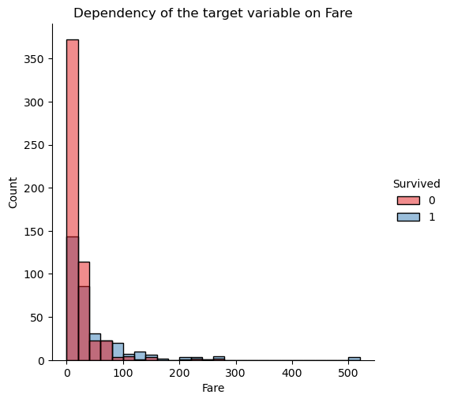

```python
# Dependenciy of the target variable on Fare
plot=sns.displot(train_df, x='Fare', hue='Survived', binwidth=20)
plot.set(title='Dependency of the target variable on Fare');
```

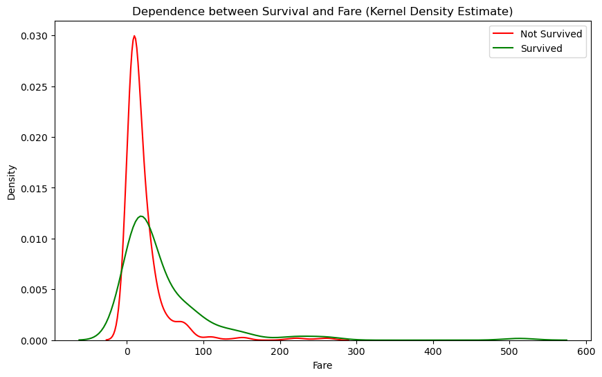

```python
plt.figure(figsize=(10, 6))
sns.kdeplot(train_df[train_df['Survived'] == 0]['Fare'], label='Not Survived', color='red')
sns.kdeplot(train_df[train_df['Survived'] == 1]['Fare'], label='Survived', color='green')

plt.title('Dependence between Survival and Fare (Kernel Density Estimate)')
plt.xlabel('Fare')
plt.ylabel('Density')
plt.legend()
plt.show()
```

#### 6. Embarked

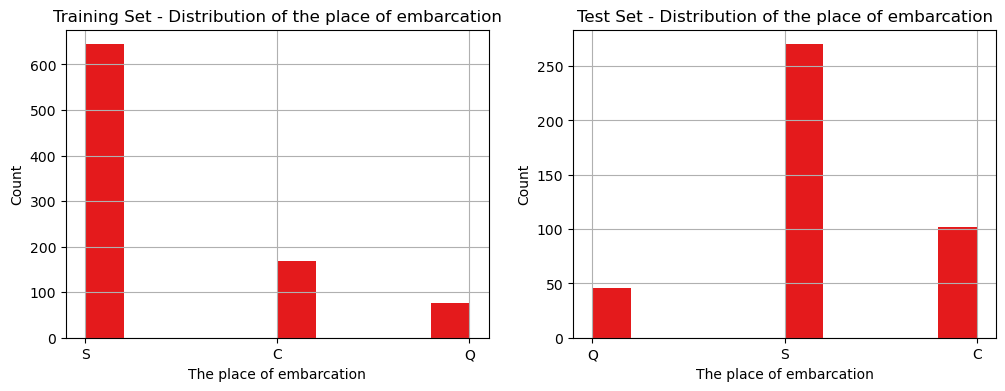

```python
fig, axes = plt.subplots(1, 2, figsize=(12, 4))

# Plot the training dataset age distribution
axes[0].set_title('Training Set - Distribution of the place of embarcation')
train_df['Embarked'].hist(ax=axes[0])
axes[0].set_xlabel('The place of embarcation')
axes[0].set_ylabel('Count')

# Plot the test dataset age distribution
axes[1].set_title('Test Set - Distribution of the place of embarcation')
test_df['Embarked'].hist(ax=axes[1])
axes[1].set_xlabel('The place of embarcation')
axes[1].set_ylabel('Count');
```

We can see that Southampton is the most popular place of embarcation, whereas Queenstown is least popular.

#### Filling missing values

```python
# Turn Age from object to numeric data type
train_df['Age']=pd.to_numeric(train_df['Age'], errors='coerce')
test_df['Age']=pd.to_numeric(test_df['Age'], errors='coerce')
```

```python
# Let's fill missing values for Age with median values
median_age_train = train_df['Age'].median()
median_age_test = test_df['Age'].median()

train_df['Age'].fillna(median_age_train, inplace=True)
test_df['Age'].fillna(median_age_test, inplace=True)
```

```python
# Drop Cabin colums as there are too many missing values
train_df.drop('Cabin', axis=1, inplace=True)
test_df.drop('Cabin', axis=1, inplace=True)
```

```python
# Drop rows with missing values for Embarked in train_df as there are only 2 values missing
train_df.dropna(subset=['Embarked'], inplace=True)
test_df.dropna(subset=['Embarked'], inplace=True)
```

```python
# Drop the row with missing values for Fare in test_df as there are only 1 value missing
test_df.dropna(subset=['Fare'], inplace=True)
```

```python
# Use dummy variables for Sex
train_df['Sex_male'] = (train_df['Sex'] == 'male').astype(int)
test_df['Sex_male'] = (test_df['Sex'] == 'male').astype(int)
```

```python
# Apply One-Hot Encoding to 'Embarked' for train dataset
train_df_encoded = pd.get_dummies(train_df, columns=['Embarked'], drop_first=True)

# Apply One-Hot Encoding to 'Embarked' for test dataset
test_df_encoded = pd.get_dummies(test_df, columns=['Embarked'], drop_first=True)
```